# The Job Market 2023.

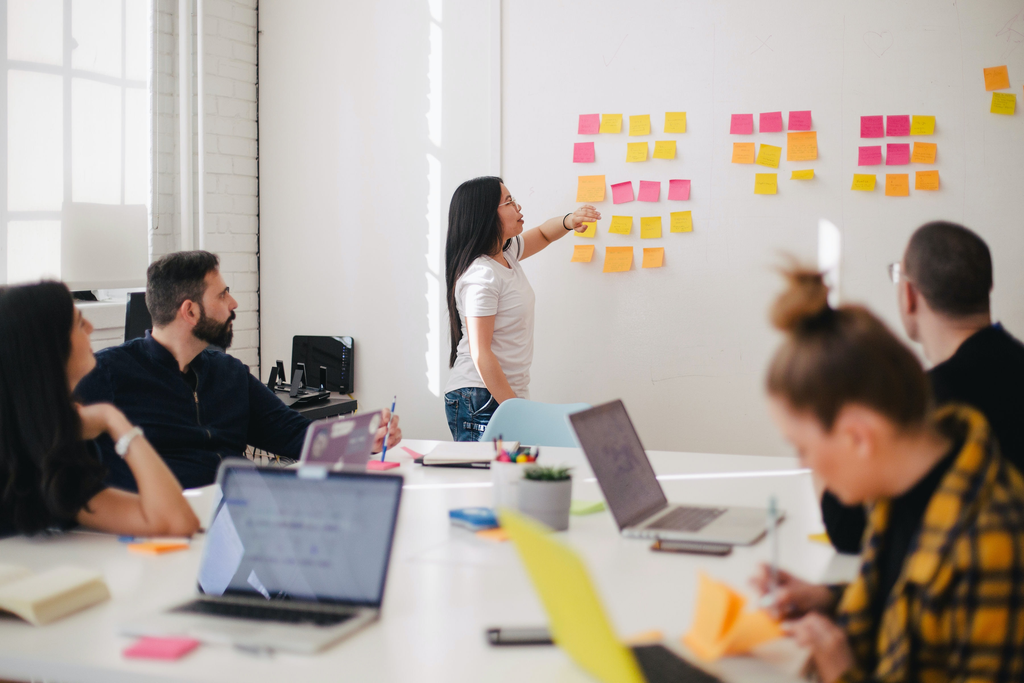

Hello! Welcome.

This is a small data visualization exercise that explores the state of the global labor market for the year 2023. The data was provided by [Amirmahdi Aboutalebi](https://www.kaggle.com/amirmahdiabbootalebi) and sourced from [Kaggle](https://www.kaggle.com/datasets/amirmahdiabbootalebi/salary-by-job-title-and-country). It has a sample of 6648 people in different industries, and it catalogues their age, education level, gender, job title, salary, years of experience, country, race, and whether they are on a senior or junior position.

```python
# Necessary packages
import numpy as np # for base data manipulation
import pandas as pd # for advanced data manipulation.
import matplotlib.pyplot as plt # for base visualization
import seaborn as sns # for better visualizations
```

# Previewing the dataset

```python
data = pd.read_csv("/kaggle/input/salary-by-job-title-and-country/Salary.csv")

data.head(10)
```

|  | Age | Gender | Education Level | Job Title | Years of Experience | Salary | Country | Race | Senior |
| --- | --- | --- | --- | --- | --- | --- | --- | --- | --- |
| 0 | 32.0 | Male | 1 | Software Engineer | 5.0 | 90000.0 | UK | White | 0 |
| 1 | 28.0 | Female | 2 | Data Analyst | 3.0 | 65000.0 | USA | Hispanic | 0 |
| 2 | 45.0 | Male | 3 | Manager | 15.0 | 150000.0 | Canada | White | 1 |
| 3 | 36.0 | Female | 1 | Sales Associate | 7.0 | 60000.0 | USA | Hispanic | 0 |
| 4 | 52.0 | Male | 2 | Director | 20.0 | 200000.0 | USA | Asian | 0 |
| 5 | 29.0 | Male | 1 | Marketing Analyst | 2.0 | 55000.0 | USA | Hispanic | 0 |
| 6 | 42.0 | Female | 2 | Product Manager | 12.0 | 120000.0 | USA | Asian | 0 |
| 7 | 31.0 | Male | 1 | Sales Manager | 4.0 | 80000.0 | China | Korean | 0 |
| 8 | 26.0 | Female | 1 | Marketing Coordinator | 1.0 | 45000.0 | China | Chinese | 0 |
| 9 | 38.0 | Male | 3 | Scientist | 10.0 | 110000.0 | Australia | Australian | 1 |

# Salary Distributions

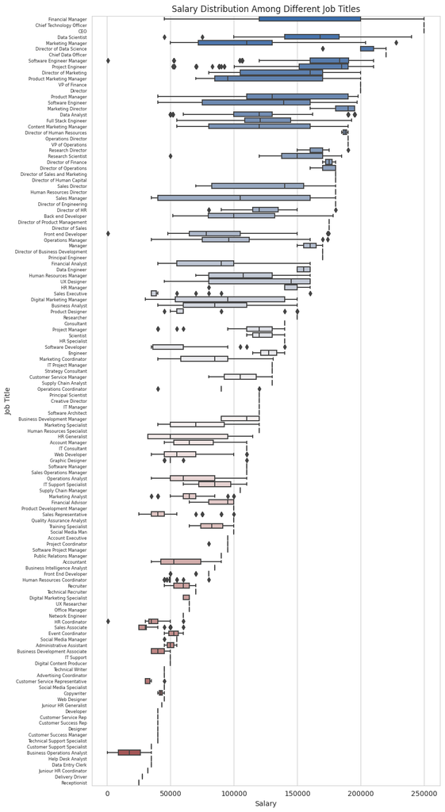

```python
# Setting the overall look of the graphs.
sns.set_style("whitegrid", {"grid.linetype" : ":"})


# The first graph.
fig, ax = plt.subplots()
fig.set_size_inches(9, 20)

sns.boxplot(x="Salary",
            y="Job Title",
            data=data.sort_values("Salary", ascending=False),
            palette="vlag").set(title="Salary Distribution Among Different Job Titles")

ax.tick_params(axis="y", which="major", labelsize=6)
```

# Top 20 High Paying Jobs

From the data above, zooming-in on the top twenty highest paying jobs.

```python
#1. Checking for the sample size
# 1.1. Grouping the dataset according to job titles
job_titles = data.groupby("Job Title")

# 1.2. Segregating the highest paying jobs
highest_paying_jobs = job_titles[["Salary"]].median().sort_values("Salary", ascending=False).head(20)

highest_paying_jobs
```

| Job Title | Salary |
| --- | --- |
| CEO | 250000.0 |
| Chief Technology Officer | 250000.0 |
| Chief Data Officer | 220000.0 |
| Director of Data Science | 210000.0 |
| Director | 200000.0 |
| VP of Finance | 200000.0 |
| Operations Director | 190000.0 |
| Marketing Director | 190000.0 |
| VP of Operations | 190000.0 |
| Director of Human Resources | 187500.0 |
| Project Engineer | 185000.0 |
| Software Engineer Manager | 183334.0 |
| Director of Human Capital | 180000.0 |
| Director of Sales and Marketing | 180000.0 |
| Human Resources Director | 180000.0 |
| Director of Engineering | 180000.0 |
| Director of Sales | 175000.0 |
| Director of Finance | 175000.0 |
| Director of Product Management | 175000.0 |
| Director of Business Development | 170000.0 |

Fishing for more information about them: The number of people in each job title.

```python
# Subsetting them from the main dataset
highest_paying_jobs = data[data["Job Title"].isin(highest_paying_jobs.index)]

highest_paying_jobs.head()
```

|  | Age | Gender | Education Level | Job Title | Years of Experience | Salary | Country | Race | Senior |
| --- | --- | --- | --- | --- | --- | --- | --- | --- | --- |
| 4 | 52.0 | Male | 2 | Director | 20.0 | 200000.0 | USA | Asian | 0 |
| 21 | 47.0 | Male | 2 | VP of Operations | 19.0 | 190000.0 | UK | White | 0 |
| 30 | 50.0 | Male | 1 | CEO | 25.0 | 250000.0 | Canada | Asian | 0 |
| 37 | 42.0 | Male | 2 | Project Engineer | 14.0 | 115000.0 | China | White | 0 |
| 41 | 48.0 | Male | 2 | Operations Director | 18.0 | 190000.0 | Canada | Black | 0 |

```python
# 1.4. Getting their sample sizes
sample_size_highest_paying_jobs = highest_paying_jobs.groupby("Job Title").count().sort_values("Salary", ascending=False) # Sorting by salary here has no intrinsic value, I just did it so that I can be able to display the most populated job position at the top.

sample_size_highest_paying_jobs
```

| Job Title | Age | Gender | Education Level | Years of Experience | Salary | Country | Race | Senior |
| --- | --- | --- | --- | --- | --- | --- | --- | --- |
| Software Engineer Manager | 376 | 376 | 376 | 376 | 376 | 376 | 376 | 376 |
| Project Engineer | 317 | 317 | 317 | 317 | 317 | 317 | 317 | 317 |
| Marketing Director | 65 | 65 | 65 | 65 | 65 | 65 | 65 | 65 |
| Director of Data Science | 57 | 57 | 57 | 57 | 57 | 57 | 57 | 57 |
| Director of Engineering | 2 | 2 | 2 | 2 | 2 | 2 | 2 | 2 |
| Director of Finance | 2 | 2 | 2 | 2 | 2 | 2 | 2 | 2 |
| Director of Human Resources | 2 | 2 | 2 | 2 | 2 | 2 | 2 | 2 |
| CEO | 1 | 1 | 1 | 1 | 1 | 1 | 1 | 1 |
| Director of Sales and Marketing | 1 | 1 | 1 | 1 | 1 | 1 | 1 | 1 |
| VP of Finance | 1 | 1 | 1 | 1 | 1 | 1 | 1 | 1 |
| Operations Director | 1 | 1 | 1 | 1 | 1 | 1 | 1 | 1 |
| Human Resources Director | 1 | 1 | 1 | 1 | 1 | 1 | 1 | 1 |
| Director of Product Management | 1 | 1 | 1 | 1 | 1 | 1 | 1 | 1 |
| Director of Sales | 1 | 1 | 1 | 1 | 1 | 1 | 1 | 1 |
| Chief Data Officer | 1 | 1 | 1 | 1 | 1 | 1 | 1 | 1 |
| Director of Human Capital | 1 | 1 | 1 | 1 | 1 | 1 | 1 | 1 |
| Director of Business Development | 1 | 1 | 1 | 1 | 1 | 1 | 1 | 1 |
| Director | 1 | 1 | 1 | 1 | 1 | 1 | 1 | 1 |
| Chief Technology Officer | 1 | 1 | 1 | 1 | 1 | 1 | 1 | 1 |
| VP of Operations | 1 | 1 | 1 | 1 | 1 | 1 | 1 | 1 |

# Top 4 Highest Paying Jobs With The Highest Number of People

So, among the 20 high paying jobs, only Software Engineer Manager, Project Engineer, Marketing Director, and Director of Data Science job titles have the most number of people. Visualizing this information.

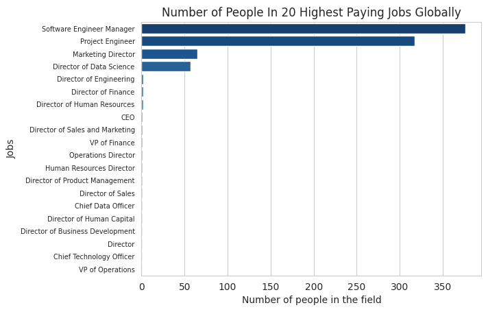

```python
# 1.5. Visualizing the sample sizes
fig, ax = plt.subplots()
sns.barplot(x="Gender",
            y=sample_size_highest_paying_jobs.index,
            data=sample_size_highest_paying_jobs,
            palette="Blues_r").set(xlabel="Number of people in the field",
                                   ylabel="Jobs",
                                   title="Number of People In 20 Highest Paying Jobs Globally")

ax.tick_params(axis="y", which="major", labelsize=7)
```

# Salaries in the Top 4 Most Crowded High Paying Jobs

Checking the salary distribution in the top 4 most populated high paying jobs.

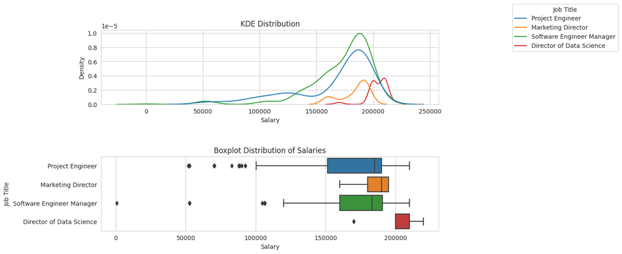

```python
# 2.1. Fishing-out the job titles of the top four most crowded high paying jobs
job_names = list(sample_size_highest_paying_jobs.index)

most_crowded_top_payers = job_names[:4]
most_crowded_top_payers


# 2.3. Fishing the information of these top four payers
crowded_top_payers = data[data["Job Title"].isin(most_crowded_top_payers)]
crowded_top_payers


# 2.4. Visualizing the salary distribution
fig, ax = plt.subplots(nrows=2, ncols=1)
fig.set_size_inches(10, 6)


sns.kdeplot(x="Salary",
            hue="Job Title",
            data=crowded_top_payers,
            ax=ax[0],
            palette="tab10").set(title="KDE Distribution")

sns.boxplot(x="Salary",
            y="Job Title",
            data=crowded_top_payers,
            ax=ax[1],
            palette="tab10").set(title="Boxplot Distribution of Salaries")

sns.move_legend(ax[0], loc="lower right", bbox_to_anchor=(1.54, 0.67))

plt.subplots_adjust(hspace=0.7)

# sns.move_legend(ax[1], loc="lower right", bbox_to_anchor=(1.54, 0.67))
```

Ok. So among the most high paying jobs, project engineer is the one with salaries that deviate more from the median. Let me replot the graphs above as histograms and see what may be causing this.

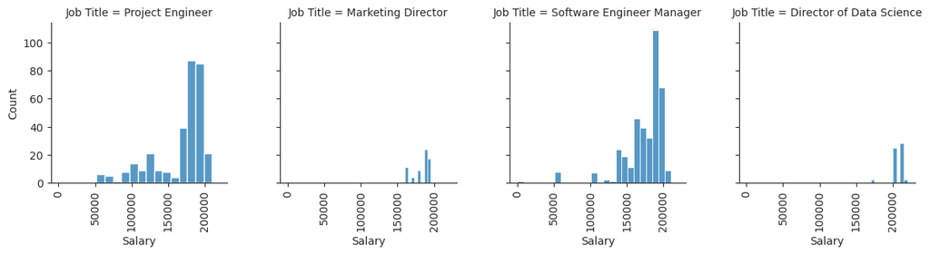

```python
# Re-fashioning the look of the graphs
sns.set_style(style="ticks")

# Plotting histograms using a FacetGrid
g = sns.FacetGrid(data=crowded_top_payers, col="Job Title")

g.map(sns.histplot, "Salary")

g.tick_params(axis="x", rotation=90)

g.set_titles(size=10)

plt.subplots_adjust(wspace=0.3)
```

So the effect is caused solely by the unequivical number of people in the lower-tier salary scale in Project Engineers than there are in other top payers. Let's see why is this.

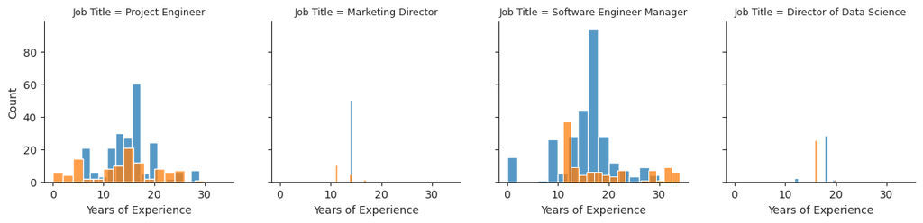

```python
# Plotting the above job titles according to the years of experience
g = sns.FacetGrid(data=crowded_top_payers, col="Job Title", hue="Gender", palette="tab10")

g.map(sns.histplot, "Years of Experience", bins=15)

g.set_titles(size=9)

plt.subplots_adjust(wspace=0.2)
```

The orange is the distribution for females, the blue is for males. Let's look at their ages.

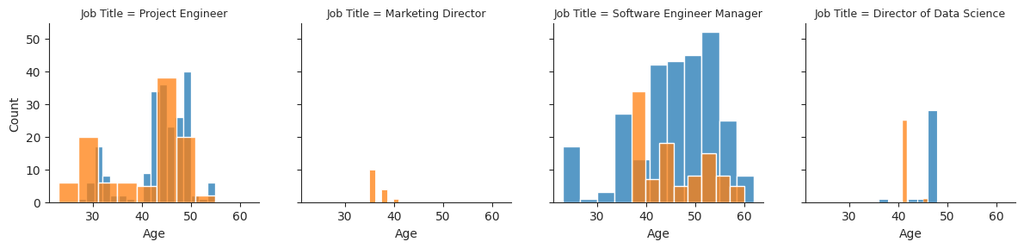

```python
# Plotting the above table according to the Age of workers there-in.
g = sns.FacetGrid(data=crowded_top_payers, col="Job Title", hue="Gender", palette="tab10", legend_out=False)

g.map(sns.histplot, "Age")

g.set_titles(size=9)

plt.subplots_adjust(wspace=0.2)
```

# Education vs Salary: Most Crowded High Paying Jobs

So, as far as the exploration above is taken into account, project engineers have more of their workers on the lower end of the salary tier because of the fact that they have more workers with 10 or less years of experience. These also happen to be younger than 40 years old. Considering the fact that this job group gave the most amount of workers among high paying jobs, that is to be expected.

Let's check the influence years of education have over salary among highest paying jobs.

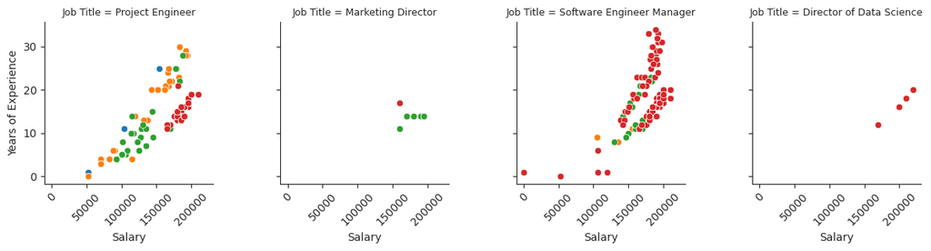

```python
# Using the FacetGrid again
g = sns.FacetGrid(data=crowded_top_payers, col="Job Title", hue="Education Level")

g.map(sns.scatterplot, "Salary", "Years of Experience")

g.tick_params(axis="x", rotation=45)

g.set_titles(size=9)

plt.subplots_adjust(wspace=0.4)
```

# Education vs Salary: All High Paying Jobs

So project engineers also generally get much higher salaries when they improve their level of education. The same applies to software engineer managers although for them, years of experience tend to bring greener grasses closer. Let's look at this in the top 20 highest paying jobs in general.

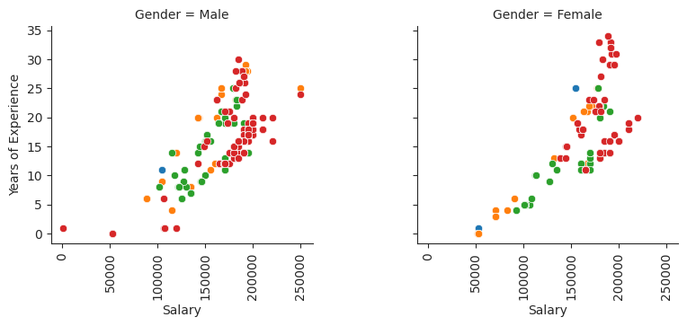

```python
# A FacetGrid again
g = sns.FacetGrid(data=highest_paying_jobs, col="Gender", hue="Education Level")

g.map(sns.scatterplot, "Salary", "Years of Experience")

g.tick_params(axis="x", rotation=90)

g.fig.set_size_inches(8, 3.5)

plt.subplots_adjust(wspace=0.4)
```

# Gender vs Education: High Paying Jobs

The pattern is the same, the higher the education, the better chances to earn a better salary. The number of each gender isn't clearly represented though. Let's get the picture of how well the variable is distributed in terms of Gender.

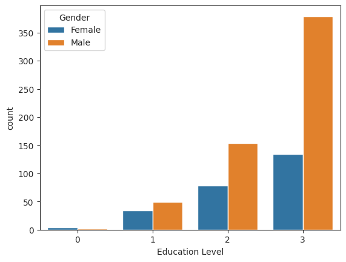

```python
# Let's check Gender agaist Education Level
sns.countplot(x="Education Level",
            hue="Gender",
            hue_order=["Female", "Male"],
            data=highest_paying_jobs,
            palette="tab10")
```

# Gender vs Education: Global View

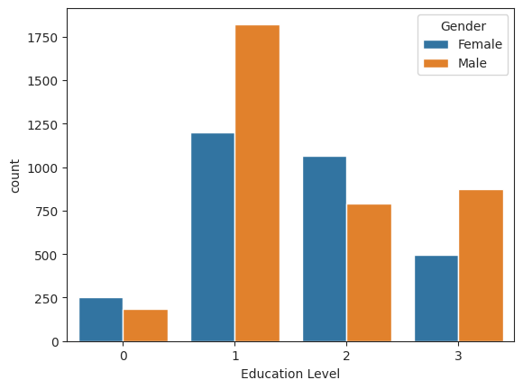

```python
# A countplot for this.
sns.countplot(x="Education Level",
            hue="Gender",
            hue_order=["Female", "Male"],
            data=data,
            palette="tab10")
```

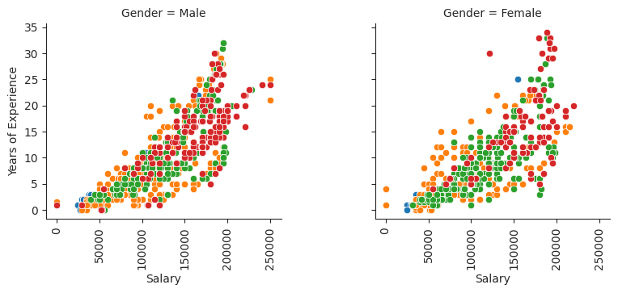

```python
# A FacetGrid again
g = sns.FacetGrid(data=data, col="Gender", hue="Education Level")

g.map(sns.scatterplot, "Salary", "Years of Experience")

g.tick_params(axis="x", rotation=90)

g.fig.set_size_inches(8, 3.5)

plt.subplots_adjust(wspace=0.4)
```

# Gender Distribution: Top 20 High Paying Jobs

Ok, so we have more women with 2 years and 0 years of education than men. The remaining years have more men in them. Looking at the distribution of Males and Females in the 20 highest paying jobs.

```
[Text(0.5, 1.0, 'Percentage of Males and Females: Top 20 High Paying Jobs.')]
```

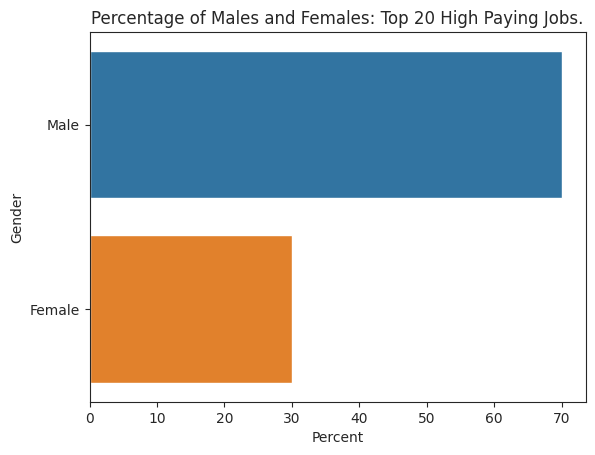

```python
# Calculating the percentage of women and men in the highest paying jobs.
highest_paying_jobs_count = highest_paying_jobs.groupby("Gender").count()

highest_paying_jobs_count["Percent"] = (highest_paying_jobs_count.iloc[:, 0] / highest_paying_jobs_count.iloc[:, 0].sum()) * 100

# The code below is mouthful, sorry for that. I was too lazy to write a readable code.
sns.barplot(x="Percent", y=highest_paying_jobs_count[["Percent"]].sort_values("Percent", ascending=False).index, data=highest_paying_jobs_count[["Percent"]].sort_values("Percent", ascending=False)).set(title="Percentage of Males and Females: Top 20 High Paying Jobs.")
```

# Gender Distribution: Global View

So, there are more men than women there. Let's check the ratio in the original dataset.

```
[Text(0.5, 1.0, 'Percentage of Males and Females: Global Dataset')]
```

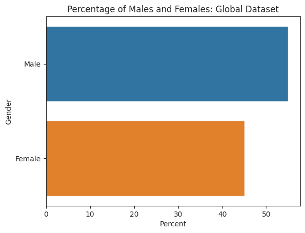

```python
# Using a barplot for this.
gender_global = data.groupby("Gender").count().sort_values("Age", ascending=False) # The "Age" column has just been used for sorting purposes.

gender_global["Percent"] = (gender_global.iloc[:, 0] / gender_global.iloc[:, 0].sum()) * 100

# Again, the mouthful code.
sns.barplot(x="Percent", y=gender_global[["Percent"]].sort_values("Percent", ascending=False).index, data=gender_global[["Percent"]].sort_values("Percent", ascending=False)).set(title="Percentage of Males and Females: Global Dataset")
```

# Salary vs Experience: Top 20 High Paying Jobs

Ok. So there are more men than women both in the global view and among the top 20 high paying jobs, though the gap is very large in the latter. The salaries of men also seem to be a little bit more inelastic to education level than the salaries of women. Let's check how salaries do against years of experience.

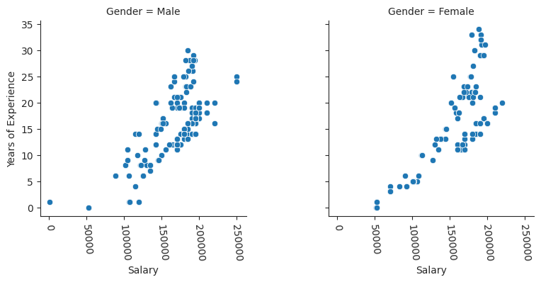

```python
# A FacetGrid Again
g = sns.FacetGrid(col="Gender", data=highest_paying_jobs,)

g.map(sns.scatterplot, "Salary", "Years of Experience")

g.tick_params(axis="x", rotation=275)

g.fig.set_size_inches(8, 4)

plt.subplots_adjust(wspace=0.4)
```

# Salary vs Experience: Global View

Ok. So in the top 20 high paying jobs, although more years among men certainly will lead to a better salary, this doesn't seem to be of much effect after 10 years of experience. The relationship among women is more streamlined, although they too seem to be divided into some two visible streams, with the women in the second stream earning a way higher salary compared to their counterparts at a similar year of experience. Let's check the same statistic for the global data to see if the pattern is the same.

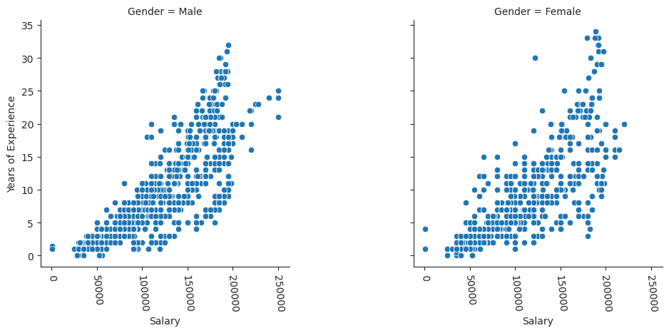

```python
g = sns.FacetGrid(col="Gender", data=data)

g.map(sns.scatterplot, "Salary", "Years of Experience")

g.tick_params(axis="x", rotation=275)

plt.subplots_adjust(wspace=0.5)
g.fig.set_size_inches(10, 5)
```

# Seniority, Gender and Years of Experience vs Salary: Top 20 High Paying Jobs

The divide seems to be there, only now in both genders. I suspect this has something to do with seniority. Let's plot the same graphs with seniority as a third factor, starting with the top 20 high paying jobs.

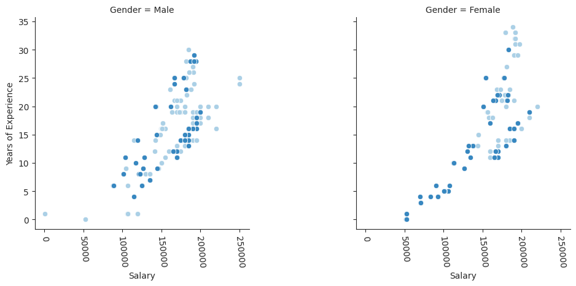

```python
g = sns.FacetGrid(col="Gender", data=highest_paying_jobs, hue="Senior", palette="Blues")

g.map(sns.scatterplot, "Salary", "Years of Experience")

g.tick_params(axis="x", rotation=275)

plt.subplots_adjust(wspace=0.5)
g.fig.set_size_inches(10, 5)
```

# Seniority, Gender, and Years of Experience vs Salary: 4 Most Crowded High Paying Jobs

Ok. So seniority definetly causes a split among males, but not so clearly among females. I suspect the different job titles might be influencing this outcome. Checking this metric for the four most crowded high paying jobs separately.

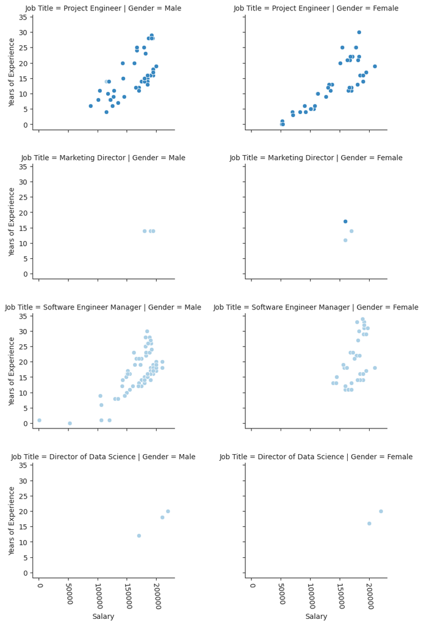

```python
g = sns.FacetGrid(col="Gender", data=crowded_top_payers, hue="Senior", row="Job Title", palette="Blues")

g.map(sns.scatterplot, "Salary", "Years of Experience")

g.tick_params(axis="x", rotation=275)

plt.subplots_adjust(hspace=0.3, wspace=0.5)
g.fig.set_size_inches(8, 12)
```

Interesting finding. The split seems to have nothing to do with seniority. As one can see, in project engineering, almost all workers are seniors, and still the split occurs. In software engineer manager position, all workers are NOT seniors, and still the split is there. Maybe age might be causing this? Let's see..

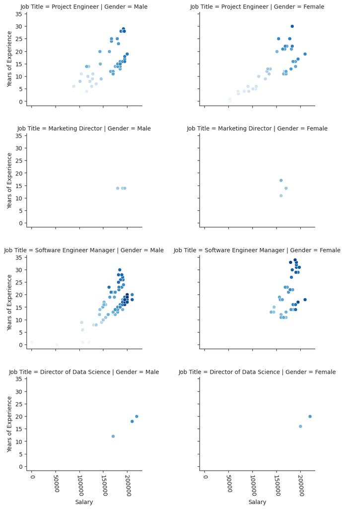

```python
g = sns.FacetGrid(col="Gender", data=crowded_top_payers, hue="Age", row="Job Title", palette="Blues")

g.map(sns.scatterplot, "Salary", "Years of Experience")

g.tick_params(axis="x", rotation=275)

plt.subplots_adjust(hspace=0.3, wspace=0.5)
g.fig.set_size_inches(8, 12)
```

# Gender, Age, and Years of Experience vs Salary: Global Dataset

We've got our culprit! Older workers tend to get higher salaries than younger ones, even at the same level of years of experience. Let's see if this holds water in the global dataset.

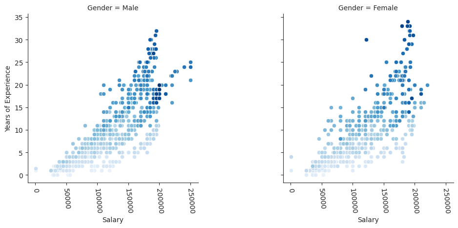

```python
g = sns.FacetGrid(col="Gender", data=data, hue="Age", palette="Blues")

g.map(sns.scatterplot, "Salary", "Years of Experience")

g.tick_params(axis="x", rotation=275)

plt.subplots_adjust(wspace=0.5)
g.fig.set_size_inches(10, 5)
```

# Ethinicities: Top 20 High Paying Jobs

Seems as such, although there are young people earning quite large salaries down in the lower right part of the graph. This has been explored deep enough. Let's check the ethinicities of workers in these industries.

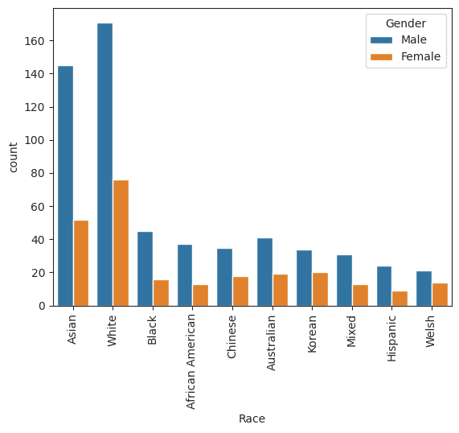

```python
# Ok. Checking the distribution of races in highest_paying jobs
fig, ax = plt.subplots()

sns.countplot(x="Race", hue="Gender", data=highest_paying_jobs, palette="tab10")

ax.tick_params(axis="x", rotation=90)
```

It seems asian and white races dominates the dataset. Let's check the countries these people come from.

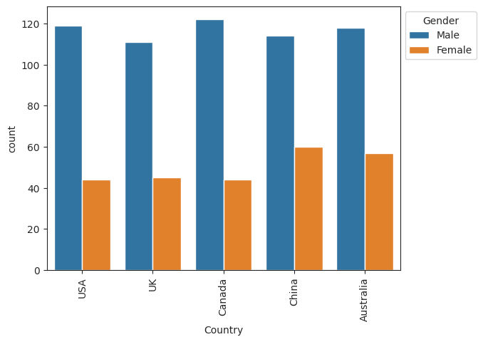

```python
# Ok. Checking the distribution of races in highest_paying jobs
fig, ax = plt.subplots()

sns.countplot(x="Country", hue="Gender", data=highest_paying_jobs, palette="tab10")

ax.tick_params(axis="x", rotation=90)

sns.move_legend(ax, loc="upper left", bbox_to_anchor=(1, 1))
```

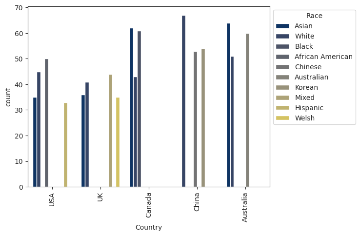

```python
# Ok. Checking the distribution of races in highest_paying jobs
fig, ax = plt.subplots()

sns.countplot(x="Country", hue="Race", data=highest_paying_jobs, palette="cividis")

ax.tick_params(axis="x", rotation=90)

sns.move_legend(ax, loc="upper left", bbox_to_anchor=(1, 1))
```

# Race and Nationality: Global view

Ok. So majority of people in the top 20 high paying jobs are Asian, White, and Blacks, with other groups following from there. Let's check the global dataset

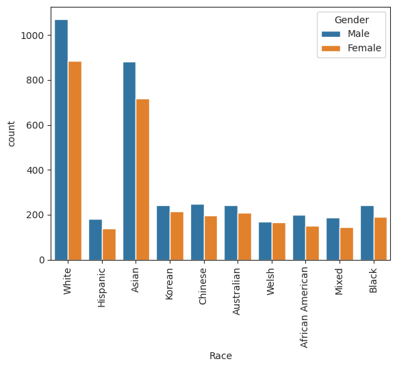

```python
# Ok. Checking the distribution of races in highest_paying jobs
fig, ax = plt.subplots()

sns.countplot(x="Race", hue="Gender", data=data, palette="tab10")

ax.tick_params(axis="x", rotation=90)
```

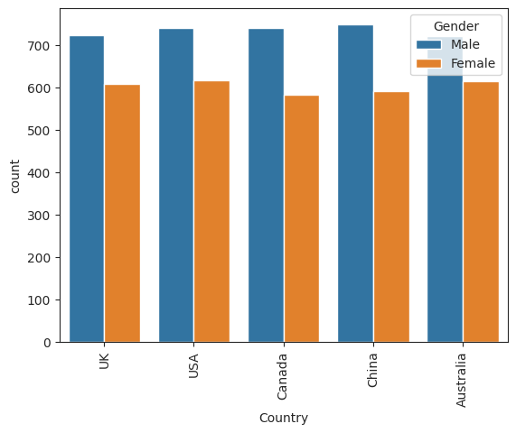

```python
# Ok. Checking the distribution of races in highest_paying jobs
fig, ax = plt.subplots()

sns.countplot(x="Country", hue="Gender", data=data, palette="tab10")

ax.tick_params(axis="x", rotation=90)
```

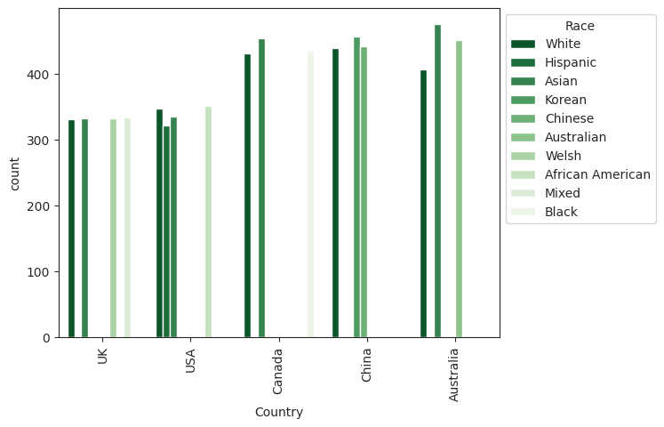

```python
# Ok. Checking the distribution of races in highest_paying jobs
fig, ax = plt.subplots()

sns.countplot(x="Country", hue="Race", data=data, palette="Greens_r")

ax.tick_params(axis="x", rotation=90)

sns.move_legend(ax, loc="upper left", bbox_to_anchor=(1, 1))
```

So the trend is almost the same, with only five countries in both the two datasets. Let's get percentages from the two datasets above.

```python
# Let's get percentages of the data above.

males_highest_paying_jobs = highest_paying_jobs[highest_paying_jobs["Gender"] == "Male"].groupby("Race").count()

females_highest_paying_jobs = highest_paying_jobs[highest_paying_jobs["Gender"] == "Female"].groupby("Race").count()

males_highest_paying_jobs["Percentage"] = (males_highest_paying_jobs.iloc[:, 0] / males_highest_paying_jobs.iloc[:, 0].sum()) * 100

females_highest_paying_jobs["Percentage"] = (females_highest_paying_jobs.iloc[:, 0] / females_highest_paying_jobs.iloc[:, 0].sum()) * 100

races_highest_paying_jobs = pd.concat([males_highest_paying_jobs[["Percentage"]].sort_values("Percentage", ascending=False),
                                       females_highest_paying_jobs[["Percentage"]].sort_values("Percentage", ascending=False)], axis=1)

races_highest_paying_jobs.columns = ["Males", "Females"]

races_highest_paying_jobs
```

| Race | Males | Females |
| --- | --- | --- |
| White | 29.280822 | 30.4 |
| Asian | 24.828767 | 20.8 |
| Black | 7.705479 | 6.4 |
| Australian | 7.020548 | 7.6 |
| African American | 6.335616 | 5.2 |
| Chinese | 5.993151 | 7.2 |
| Korean | 5.821918 | 8.0 |
| Mixed | 5.308219 | 5.2 |
| Hispanic | 4.109589 | 3.6 |
| Welsh | 3.595890 | 5.6 |

```python
# The Global Scale

male_race_counts = data[data["Gender"] == "Male"].groupby("Race").count()

male_race_counts

female_race_counts = data[data["Gender"] == "Female"].groupby("Race").count()

female_race_counts

male_race_counts["Percentage"] = (male_race_counts.iloc[:, 0] / male_race_counts.iloc[:, 0].sum()) * 100

female_race_counts["Percentage"] = (female_race_counts.iloc[:, 0] / female_race_counts.iloc[:, 0].sum()) * 100

race_counts = pd.concat([male_race_counts[["Percentage"]].sort_values("Percentage", ascending=False),
                         female_race_counts[["Percentage"]].sort_values("Percentage", ascending=False)], axis=1)

race_counts

race_counts.columns = ["Males", "Females"]

race_counts
```

| Race | Males | Females |
| --- | --- | --- |
| White | 29.201852 | 29.372718 |
| Asian | 24.053391 | 23.763691 |
| Chinese | 6.728412 | 6.505144 |
| Australian | 6.619450 | 6.936608 |
| Black | 6.619450 | 6.372386 |
| Korean | 6.592209 | 7.135745 |
| African American | 5.475347 | 5.011616 |
| Mixed | 5.148461 | 4.812479 |
| Hispanic | 4.985018 | 4.613342 |
| Welsh | 4.576410 | 5.476269 |

# Seniority: Both Views

```python
# Let's check the number of seniors in highest paying jobs whose working experience is lower than 5 years.
young_rich_seniors = highest_paying_jobs[(highest_paying_jobs["Years of Experience"] <= 5) & (highest_paying_jobs["Senior"] == 1)]

young_rich_seniors
```

|  | Age | Gender | Education Level | Job Title | Years of Experience | Salary | Country | Race | Senior |
| --- | --- | --- | --- | --- | --- | --- | --- | --- | --- |
| 1219 | 27.0 | Male | 1 | Project Engineer | 4.0 | 115000.0 | USA | White | 1 |
| 2405 | 24.0 | Female | 0 | Project Engineer | 1.0 | 52731.0 | Canada | Black | 1 |
| 2480 | 24.0 | Female | 0 | Project Engineer | 1.0 | 52731.0 | Canada | Black | 1 |
| 2523 | 30.0 | Female | 2 | Project Engineer | 5.0 | 106278.0 | China | Korean | 1 |
| 2537 | 23.0 | Female | 1 | Project Engineer | 0.0 | 51831.0 | Australia | Asian | 1 |
| 2581 | 30.0 | Female | 2 | Project Engineer | 5.0 | 100425.0 | UK | White | 1 |
| 2588 | 28.0 | Female | 1 | Project Engineer | 4.0 | 70022.0 | USA | White | 1 |
| 2768 | 30.0 | Female | 2 | Project Engineer | 4.0 | 92438.0 | China | White | 1 |
| 2782 | 23.0 | Female | 1 | Project Engineer | 0.0 | 52831.0 | Canada | White | 1 |
| 2826 | 30.0 | Female | 2 | Project Engineer | 5.0 | 100867.0 | China | Chinese | 1 |
| 2833 | 28.0 | Female | 1 | Project Engineer | 3.0 | 70397.0 | USA | Hispanic | 1 |
| 2851 | 30.0 | Female | 2 | Project Engineer | 5.0 | 101733.0 | USA | White | 1 |
| 2858 | 28.0 | Female | 1 | Project Engineer | 3.0 | 70397.0 | Australia | White | 1 |
| 2876 | 30.0 | Female | 2 | Project Engineer | 5.0 | 101733.0 | China | White | 1 |
| 2886 | 30.0 | Female | 2 | Project Engineer | 4.0 | 92438.0 | Canada | Black | 1 |
| 2900 | 23.0 | Female | 1 | Project Engineer | 0.0 | 52831.0 | China | White | 1 |
| 2944 | 30.0 | Female | 2 | Project Engineer | 5.0 | 100867.0 | Australia | Australian | 1 |
| 2951 | 28.0 | Female | 1 | Project Engineer | 3.0 | 70397.0 | USA | Asian | 1 |
| 2969 | 30.0 | Female | 2 | Project Engineer | 5.0 | 101733.0 | China | Chinese | 1 |
| 2976 | 28.0 | Female | 1 | Project Engineer | 3.0 | 70397.0 | China | Korean | 1 |
| 2994 | 30.0 | Female | 2 | Project Engineer | 5.0 | 101733.0 | Australia | Australian | 1 |
| 3004 | 30.0 | Female | 2 | Project Engineer | 4.0 | 92438.0 | USA | Hispanic | 1 |
| 3018 | 23.0 | Female | 1 | Project Engineer | 0.0 | 52831.0 | USA | Asian | 1 |
| 3062 | 30.0 | Female | 2 | Project Engineer | 5.0 | 100867.0 | Canada | Black | 1 |
| 3069 | 28.0 | Female | 1 | Project Engineer | 4.0 | 82944.0 | China | Chinese | 1 |

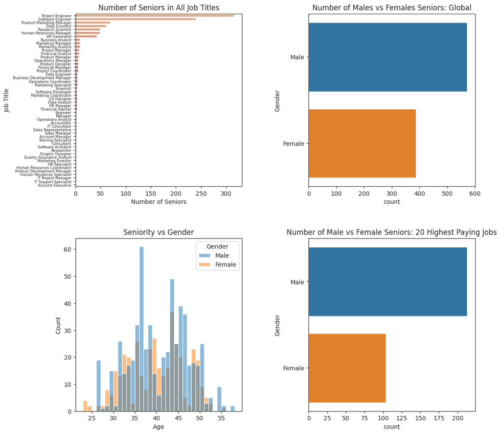

```python
# Interesting finding. It seems most young seniors in the highest paying jobs are women. Let's check the whole data to see if there is such representation among all seniors.
seniors = data[data["Senior"] == 1]


# Displaying their gender distribution
fig, ax = plt.subplots(2, 2)
fig.set_size_inches(12, 12)


# Shows The Distribution of The Gender and Age of Seniors
sns.histplot(x="Age", hue="Gender", bins=35, data=seniors, ax=ax[1, 0], palette="tab10").set(title="Seniority vs Gender")


# Shows the total number of male and female seniors in all job titles.
sns.countplot(y="Gender", data=seniors, ax=ax[0, 1], palette="tab10").set(title="Number of Males vs Females Seniors: Global")


# Shows the number of Seniors on all job titles (The "Age" column was just used for sorting and displaying purposes. There isn't any intrinsic meaning in choosing it).
modified_frame = seniors.groupby("Job Title").count().sort_values("Age", ascending=False) # Created so that one can group job titles according to the number of seniors they have.

sns.barplot(x="Age", y=modified_frame.index, data=modified_frame, ax=ax[0, 0], palette="flare").set(title="Number of Seniors in All Job Titles", xlabel="Number of Seniors")


# Shows the number of male and female seniors in the 20 highest paying jobs
sns.countplot(y="Gender", data=highest_paying_jobs[highest_paying_jobs["Senior"] == 1], ax=ax[1,1], order=["Male", "Female"], palette="tab10").set(title="Number of Male vs Female Seniors: 20 Highest Paying Jobs")

ax[0,0].tick_params(axis="y", which="major", labelsize=6)

plt.subplots_adjust(wspace=0.4, hspace=0.3)
```

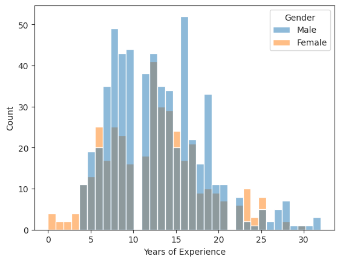

```python
# Let's check seniority vs years of experience
sns.histplot(x="Years of Experience",
             hue="Gender",
             bins=35,
             data=seniors,
             palette="tab10")
```

```python
# Let's see the distribution of seniors among highest paying jobs

# Subsetting rich seniors
rich_seniors = highest_paying_jobs[highest_paying_jobs["Senior"] == 1]

# Grouping rich seniors according to job title
jobs_rich_seniors = rich_seniors.groupby("Job Title")

# Counting rich seniors in each job title
jobs_rich_seniors_count = jobs_rich_seniors.count()

jobs_rich_seniors_count
```

| Job Title | Age | Gender | Education Level | Years of Experience | Salary | Country | Race | Senior |
| --- | --- | --- | --- | --- | --- | --- | --- | --- |
| Marketing Director | 1 | 1 | 1 | 1 | 1 | 1 | 1 | 1 |
| Project Engineer | 316 | 316 | 316 | 316 | 316 | 316 | 316 | 316 |

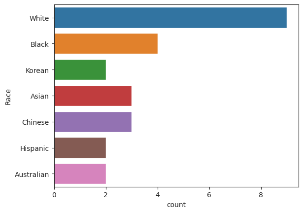

```python
# Let's check the ethinicities of young_rich_seniors

sns.countplot(y="Race", data=young_rich_seniors, palette="tab10")
```

```python
# Let's check the jobs of seniors in the global dataset whose years of experience is less than five.
young_seniors = seniors[seniors["Years of Experience"] <= 5]

young_seniors


# Grouping according to job titles.
jobs_young_seniors = young_seniors.groupby("Job Title")[["Years of Experience", "Age"]].median()

jobs_young_seniors
```

| Job Title | Years of Experience | Age |
| --- | --- | --- |
| HR Generalist | 4.0 | 29.0 |
| Human Resources Manager | 4.0 | 29.0 |
| Product Marketing Manager | 5.0 | 26.0 |
| Project Engineer | 4.0 | 28.0 |
| Software Engineer | 5.0 | 28.0 |

```python
# Let's check all job titles where seniors come from

job_seniors = seniors.groupby("Job Title").count().sort_values("Age", ascending=False)

job_seniors


# Calculating percentage of the number of seniors in each job title among the total amount of seniors
job_seniors["Percentage"] = (job_seniors.iloc[:, 0] / job_seniors.iloc[:, 0].sum()) * 100

job_seniors_percentages = job_seniors[["Percentage", "Senior"]]

job_seniors_percentages.head()
```

| Job Title | Percentage | Senior |
| --- | --- | --- |
| Project Engineer | 32.950991 | 316 |
| Software Engineer | 25.026069 | 240 |
| Product Marketing Manager | 7.194995 | 69 |
| Data Scientist | 6.360792 | 61 |
| Research Scientist | 5.109489 | 49 |

```python
# Lets check the median age, ethnicities and countries of origin of seniors

# Checking ethinicities of the highest paying jobs
ethnicities_rich_seniors = rich_seniors.groupby("Race").count().sort_values("Senior", ascending=False)

display(ethnicities_rich_seniors)


# Checking ethnicities of all seniors
ethnicities_seniors = seniors.groupby("Race").count().sort_values("Senior", ascending=False)

display(ethnicities_seniors)
```

| Race | Age | Gender | Education Level | Job Title | Years of Experience | Salary | Country | Senior |
| --- | --- | --- | --- | --- | --- | --- | --- | --- |
| White | 98 | 98 | 98 | 98 | 98 | 98 | 98 | 98 |
| Asian | 73 | 73 | 73 | 73 | 73 | 73 | 73 | 73 |
| Australian | 26 | 26 | 26 | 26 | 26 | 26 | 26 | 26 |
| Black | 23 | 23 | 23 | 23 | 23 | 23 | 23 | 23 |
| African American | 20 | 20 | 20 | 20 | 20 | 20 | 20 | 20 |
| Korean | 20 | 20 | 20 | 20 | 20 | 20 | 20 | 20 |
| Chinese | 17 | 17 | 17 | 17 | 17 | 17 | 17 | 17 |
| Mixed | 17 | 17 | 17 | 17 | 17 | 17 | 17 | 17 |
| Hispanic | 12 | 12 | 12 | 12 | 12 | 12 | 12 | 12 |
| Welsh | 11 | 11 | 11 | 11 | 11 | 11 | 11 | 11 |

| Race | Age | Gender | Education Level | Job Title | Years of Experience | Salary | Country | Senior |
| --- | --- | --- | --- | --- | --- | --- | --- | --- |
| White | 311 | 311 | 311 | 311 | 311 | 311 | 311 | 311 |
| Asian | 215 | 215 | 215 | 215 | 215 | 215 | 215 | 215 |
| Black | 68 | 68 | 68 | 68 | 68 | 68 | 68 | 68 |
| Korean | 63 | 63 | 63 | 63 | 63 | 63 | 63 | 63 |
| Chinese | 62 | 62 | 62 | 62 | 62 | 62 | 62 | 62 |
| Australian | 55 | 55 | 55 | 55 | 55 | 55 | 55 | 55 |
| African American | 49 | 49 | 49 | 49 | 49 | 49 | 49 | 49 |
| Mixed | 47 | 47 | 47 | 47 | 47 | 47 | 47 | 47 |
| Welsh | 45 | 45 | 45 | 45 | 45 | 45 | 45 | 45 |
| Hispanic | 44 | 44 | 44 | 44 | 44 | 44 | 44 | 44 |

# Conclusion

- Although the dataset is very insightful, it lacks the quality to represent the whole world in this matter. A dataset that had countries in each geo-economical income group would've been more accurate.
- For the next uploader of this kind of data, it will be very helpful if one mentions the units in which their variables are expressed in, such as salary is in USD, or years of education as whether the university education or else.